# Unemployment By United States Metro Area Over The Last 11 Months.

## Regional Unemployment Percentages By Month For Sample Regions:

Since the general country wide information doesn’t really tell a detailed story, I want to know if within specific selected regions, the precentage of citizens within a metro region remains in a downward slope. For this test I have selected New York City’s region, Chicago’s region, and Los Angeles’s region since that would cover the East Coast, Midwest, and Pacific greater regions of the country below in their respective order. We can tell that from the information provided below, that New York City’s and LA’s numbers show that there is a steady decline over the last year of unemployed individuals amongst their region, this so far agrees with our original story. Chicago’s numbers, however, tell a different story that confirms that the national data shows a decline of unemployed individuals in which the decline is greater than the amount of regional inclines but both exist within the dataset.

### New York City:

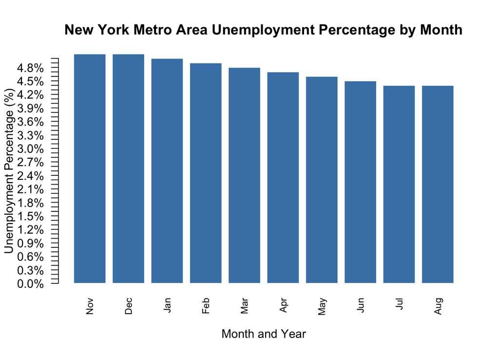

### Chicago Illinois:

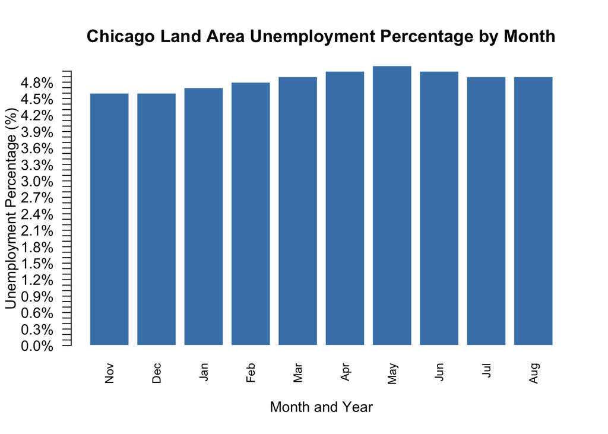

### Los Angeles:

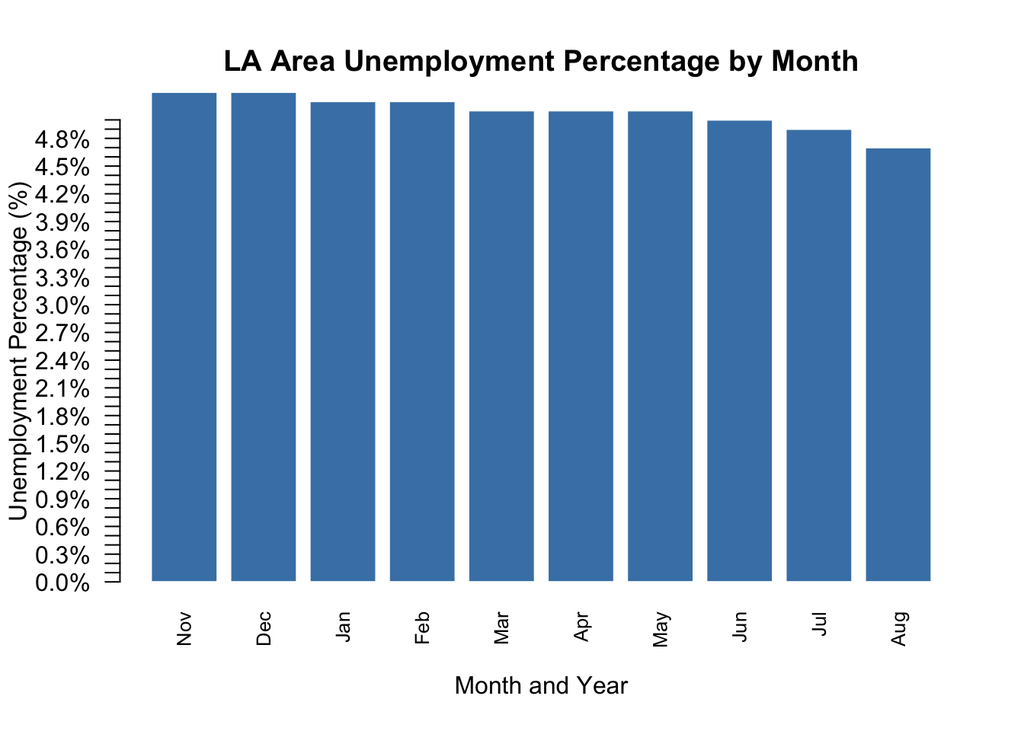